# Understanding AI: From Chatbots to Agents to AGI

> 📌 **About this material:** This content is adapted from [POLI-LIT: Political Science Data Literacy Module](https://www.edwinachen.com/teaching/poli-lit), developed by Edwina Chen & Insu Hwang at the University of South Carolina. The material below covers the fundamentals of AI, generative AI, large language models, AI agents, and AI in industry. While some details may not reflect the very latest developments — AI evolves rapidly — the core concepts and frameworks remain current and relevant.

> 📚 **Want to learn more?** Check out these resources:  
> - [IBM Technology YouTube Playlists](https://www.youtube.com/@IBMTechnology/playlists) — short, clear explainer videos on AI topics  
> - [Garnet AI Fluency 101](https://sc.edu/about/offices_and_divisions/division_of_information_technology/ai/garnet_ai_fluency_101/index.php) — USC’s free short online course on AI fundamentals  
> - [USC Library AI Workshops](https://libcal.library.sc.edu/calendar/workshops?cid=16861&t=g&d=0000-00-00&cal=16861&ct=68400&inc=0) — hands-on workshops offered through the USC library system

# 1 Understanding AI

Before we talk about how AI is changing industries and society, let’s first understand what we actually mean by “Artificial Intelligence.” The term covers many ideas, from a simple phone assistant to tools like ChatGPT that can write essays or code. Think of this section as building blocks — each concept adds another layer of understanding.

## 1.1 What Is AI, Generative AI, and LLM?

### 1.1.1 Artificial Intelligence (AI)

**Artificial Intelligence (AI)** means using computers to do tasks that normally require human thinking.  
For example:

- When Netflix recommends a movie you might like.
- When your phone unlocks after recognizing your face.
- When Google Maps finds the fastest route to school.

In all these examples, the computer is using data — what it has seen before — to make a smart choice.

AI is the **broadest term** that covers all kinds of “smart” technologies we use daily.

> ✏️ **Simple definition:** AI is when computers are designed to mimic human thinking — by learning from data or experience and then using that to make decisions, predictions, or even generate new content.

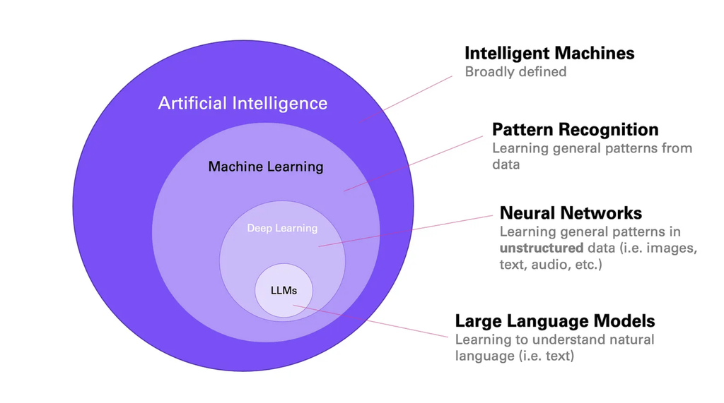

This diagram shows how different types of AI fit inside each other. **Source:** Stöffelbauer (2023), *How Large Language Models Work.*

### 1.1.2 Machine Learning (ML)

Inside the big world of AI, there is a smaller part called **Machine Learning**. Machine Learning means teaching computers to find patterns and improve with experience — just like how people learn from practice.

Example:

- A spam filter in your email learns which messages are spam after looking at thousands of examples.
- A music app learns what songs you like and recommends similar ones.

> ✏️ **Simple definition:** Machine Learning helps computers learn automatically from data, without being told every single rule.

### 1.1.3 Deep Learning (DL)

**Deep Learning** is a special kind of machine learning that uses something called *neural networks* — an innovative way of organizing the computer’s learning process (they are called “neural” because they mimic how neurons in our brain signal one another).

A *deep learning algorithm* is a type of neural network that has more than three layers — including input, hidden, and output layers. This idea is shown in the diagram below:

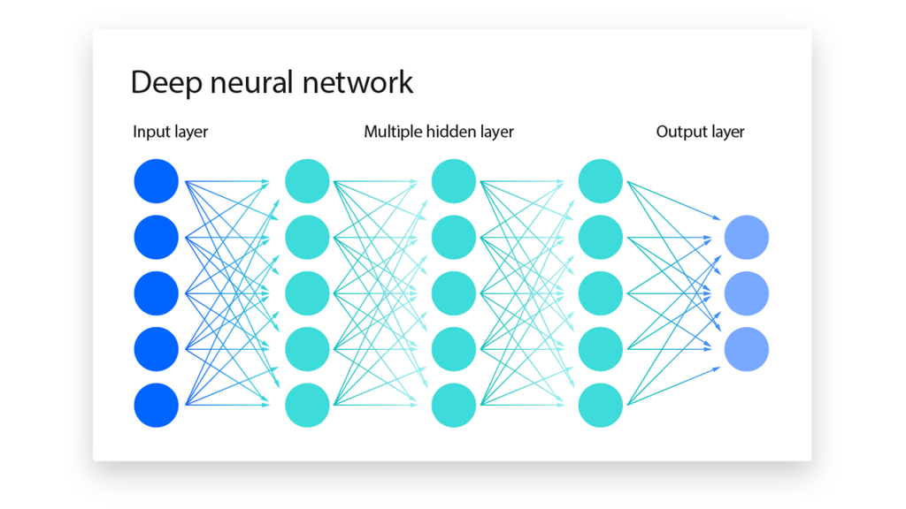

**Source:** IBM Data and AI Team (2024), *AI vs. machine learning vs. deep learning vs. neural networks.*

The “deep” in deep learning refers to the depth of layers in a neural network. This helps it recognize complex patterns like faces, voices, or handwriting.

Example:

- Your phone’s camera can recognize your pet in pictures.
- Speech-to-text programs like Siri or Alexa understand spoken words.

> ✏️ **Simple definition:** Deep Learning is a more advanced type of machine learning that helps computers recognize very complex patterns — like images or voices.

### 1.1.4 Generative AI (GenAI)

Now comes **Generative AI**, the kind that can *create* things.

Instead of just identifying or predicting, this type of AI can generate **new content** — text, images, music, or code — based on what it has learned.

Examples include:

- **ChatGPT:** writes text or code.
- **DALL·E:** creates new images from text prompts.
- **Google Gemini or Copilot:** helps summarize, write, and brainstorm ideas.

> ✏️ **Simple definition:** Generative AI can create new things — like essays, pictures, or programs — by recognizing patterns in huge amounts of data.

**Think of it like this:**  
If you’ve read hundreds of stories, you could probably write one that *sounds similar* — even if it’s completely new. That’s what Generative AI does — it learns the style and structure, then creates something new from it.

### 1.1.5 Large Language Models (LLMs)

**Large Language Models** (LLMs) are a type of GenAI focused on text. These models are trained on an enormous amount of text — from books, websites, articles, and code — to learn how people use language.

Take ChatGPT for example. “GPT” stands for Generative Pre-trained Transformer:

- **Generative:** It creates (generates) new text.
- **Pre-trained:** It was trained on a massive amount of text before you ever use it.
- **Transformer:** This is the specific kind of AI model it uses — great at understanding language.

> ✏️ **Simple definition:** LLMs are advanced programs that predict what to say next by recognizing language patterns from huge amounts of text.

LLMs don’t **think** or **understand** like humans. They simply **predict** what word (or sentence) should come next, based on patterns they’ve seen before. Sometimes they can make up information that sounds right but isn’t (this is called “hallucination”). That’s why it’s important to **double-check facts** using reliable sources.

### 1.1.6 How These Concepts Fit Together

| **Concept** | **What It Means** | **Example in Action** | **Analogy** |
| --- | --- | --- | --- |
| **AI** | The overall idea of making computers act smart. | A self-driving car recognizing stop signs. | The “umbrella” term for all smart systems. |
| **ML** | A way for computers to learn from data. | An email filter learning what counts as spam. | Like learning by doing — more examples = better. |
| **DL** | ML that uses many layers to recognize complex patterns. | Siri understanding your voice commands. | Like the brain — many layers processing step by step. |
| **GenAI** | AI that creates new content. | DALL·E generating an image from a prompt. | Like a student who paints something new after studying many artworks. |
| **LLMs** | The system behind tools like ChatGPT. | ChatGPT writing code or essays. | Like an advanced autocomplete that has read the internet. |

## 1.2 Limitations and Ethics of Using GenAI

As you begin using AI tools in your learning and daily work, it is important to think carefully about what AI can and cannot do.

Generative AI is a powerful tool for writing, coding, and problem solving, but it is not a human brain. It does not truly *understand* language or meaning — it simply imitates what understanding looks like by recognizing patterns in data.

> 🔍 **Not a Human Brain**  
> AI systems mimic reasoning but *do not actually think, understand, or know the truth*. They produce text or code by predicting what is likely to come next based on what they have seen in their training data. AI can sound intelligent because its responses are often fluent and well-structured, but this fluency does not mean understanding. Unlike people, AI *does not experience the world, form opinions, or evaluate meaning — it only predicts*.

### 1.2.1 Limitations of AI

Even though Generative AI can produce impressive results, it has clear limits:

- **Can generate wrong or made-up information (“hallucinations”).**  
  Sometimes AI invents facts, names, or citations that sound believable but are not real.
- **Lacks real-world context unless you provide it.**  
  It only knows what is written in your prompt; it cannot “guess” what you mean.
- **Can repeat social or data biases.**  
  Because AI learns from human data, it may repeat stereotypes or biased language found in its training material.
- **Does not reason or understand ideas.**  
  It imitates the structure of language, but it cannot truly analyze meaning or intent.

In short, AI is a tool for generating patterns — not a system that understands truth or logic. You should always be the one interpreting, questioning, and verifying what it produces.

### 1.2.2 Ethical Use of AI

When using AI in academic or professional settings, ethical use means using it to **support your own thinking, not to replace it.**

- **Always fact-check AI-generated answers.** Verify statistics, quotes, and claims using trusted sources.
- **Never submit AI output as your own work.** Passing off AI-generated writing as personal writing is a form of plagiarism.
- **Use AI for learning, not shortcutting.** Ask it to *explain*, *summarize*, or *suggest*, but make sure you still think critically about the result.
- **Remember:** AI does not “know” — it predicts. You are responsible for the accuracy, originality, and integrity of any work that includes AI assistance.

Using AI responsibly means developing judgment — understanding when it helps you think and when it might mislead you.

### 1.2.3 Why Can AI Generate Things So Well (Even Without Thinking)?

You might wonder how AI can produce such fluent text or realistic answers even though it does not think. The reason lies in how these systems are trained.

AI systems like LLMs are trained on **massive amounts of text and data** from books, websites, and code. They learn **probabilities** — given a prompt, they predict which words or phrases are most likely to come next based on patterns in the training data. Because of their size and exposure to so much language, they can **mimic human-like writing or reasoning** very convincingly.

However, they do **not understand meaning** the way humans do. They have **no goals, beliefs, or consciousness** — they simply select the next most likely token (word or symbol). This is why their answers can appear smart and fluent, yet sometimes are **inaccurate, inconsistent, or shallow** in reasoning.

> *LLMs are like a 12-year-old who has read every classic novel, wiki entry, and Reddit thread — in every language, ever — and is trying to sound smart like an adult. But they don’t actually understand what any of it means… Now imagine that 12-year-old is a robot who doesn’t feel and experience the world like we do…* — Chen (2025)

#### 1.2.3.1 Recommended Resources

- [**The Benefits and Limitations of Generative AI: Harvard Experts Answer Your Questions**](https://harvardonline.harvard.edu/blog/benefits-limitations-generative-ai)
- [**The Limits of AI: Generative AI, NLP, AGI, and What’s Next? (Microsoft Research)**](https://www.microsoft.com/en-us/research/blog/the-limits-of-ai-generative-ai-nlp-agi-and-whats-next/)
- [**AI, Machine Learning, Deep Learning and Generative AI Explained (YouTube)**](https://youtu.be/qYNweeDHiyU?si=gCa9GosBi2TpsjLY)

## 1.3 Knowledge Check 1

**1. AI systems like ChatGPT truly understand what they are saying.**

a) True

b) False

**2. What does "hallucination" mean in the context of AI?**

a) The AI generates confident but false or made-up information

b) The AI starts dreaming like a human

c) The AI refuses to answer a question

**3. Why can LLMs produce such fluent and convincing text?**

a) They understand the meaning of every word

b) They are programmed with every possible answer

c) They predict the most likely next word based on patterns in massive training data

# 2 Beyond Chatbots: AI Agents and AGI

The AI tools most people interact with today — ChatGPT, Claude, Gemini — are chatbots. You type a question, you get a response. But AI is evolving beyond that conversational format. In this section, we look at two important developments: **AI agents** (what’s happening right now) and **AGI** (what’s being debated for the future).

## 2.1 AI Agents: From Chatting to Doing

A chatbot answers one question at a time. You ask, it replies, you ask again. An **AI agent** works differently. You give it a *goal* rather than a single instruction, and it takes a series of steps on its own to reach that goal.

An agent can:

- Break a big task into smaller ones
- Decide what to do first
- Use other tools along the way (search the web, run code, open files)
- Check whether its own work is going well
- Adjust its plan when something doesn’t work

Some AI agents can even **view your screen and take control of your computer** — browsing websites, clicking buttons, filling out forms, and completing tasks on your behalf. If you’ve seen the Marvel movies, think of **JARVIS** (Tony Stark’s AI assistant) — an intelligent system that doesn’t just answer questions, but actually *operates* things in the real world. That’s the direction AI agents are heading, though we’re still in early stages compared to the movies.

**A concrete example:**

- **Chatbot:** You ask “How do I schedule a meeting?” → It explains the steps.
- **AI Agent:** You say “Schedule a meeting with the team next Tuesday” → It checks calendars, finds an open time, sends invitations, books a room, and follows up with people who don’t respond.

The keyword is **autonomy** — but it’s limited autonomy, and the limit matters. The best agents in 2026 still need human oversight, especially for high-stakes decisions.

> ✏️ **Simple definition:** AI agents are AI systems that can take a series of actions toward a goal — not just answer a single question. Think of them as AI that *does things*, not just AI that *says things*.

### 2.1.1 Three Levels of AI Interaction

| Level | What It Does | Example |
| --- | --- | --- |
| **Level 1: Chatbot** | Answers questions when asked | ChatGPT answering “what’s the capital of France?” |
| **Level 2: Assistant** | Uses a tool or two when you ask | AI searching the web or running a calculation for you |
| **Level 3: Agent** | Strings many abilities together toward a goal you set once | AI that researches a topic, gathers sources, organizes findings, and gives you a summary |

2026 is the year Level 3 became genuinely practical rather than experimental — though the gap between what gets *marketed* as an AI agent and what actually works as one is still significant.

### 2.1.2 AI Agents in the News

This is not just a tech industry story — AI agents are already raising questions in education, work, and daily life.

[figure not shown]

**Source:** The New York Times (2025). As AI agents become capable of navigating websites and completing multi-step tasks autonomously, they are being used by some students to complete entire online courses — raising questions about academic integrity and the value of online education.

> 💬 **Discussion:** What tasks in your daily life would you trust an AI agent to handle? What tasks would you *not* trust it with? Why?

#### 2.1.2.1 Recommended Resources

- [**Agentic AI, Explained (MIT Sloan)**](https://mitsloan.mit.edu/ideas-made-to-matter/agentic-ai-explained)
- [**What Are AI Agents? (YouTube — IBM Technology)**](https://www.youtube.com/watch?v=Zqno_vux6d8)

## 2.2 AGI: Artificial General Intelligence

### 2.2.1 What Is AGI?

All the AI we’ve discussed so far — chatbots, agents, image generators — is considered **narrow AI** (sometimes called “weak AI”). These systems are designed to perform specific tasks, and they can be very good at those tasks, but they can’t transfer their skills across domains the way humans do.

**AGI** refers to a hypothetical AI system that could match human-level cognitive ability across *any* intellectual task — reasoning, learning, problem-solving, and adapting in any domain, without needing task-specific training.

> ✏️ **Simple definition:** AGI would be AI that can do anything a human mind can do — not just one task, but all of them.

### 2.2.2 Where Are We Now?

Whether AGI has been achieved is one of the most debated questions in technology right now — and there is no settled answer. Some industry leaders (including the CEOs of Nvidia and OpenAI) have claimed AGI is here or nearly here, while independent benchmarks and many researchers disagree. There is no universally accepted definition of AGI, and no independent body has verified any company’s claims. What we do know is that AI capabilities are advancing extremely fast, and the gap between what AI can and cannot do is shrinking rapidly.

> 🔑 **Key takeaway:** Whether it arrives next year or in a decade, AGI-level intelligence will likely be part of our lives in the not-too-distant future. Understanding the basics of how AI works *now* — its capabilities, its limits, and the choices embedded in its design — prepares you to navigate that future thoughtfully.

> 💬 **Discussion:** If AI becomes smarter than us, what would happen? How should society prepare?

## 2.3 Knowledge Check 2

**1. What is the main difference between a chatbot and an AI agent?**

a) An AI agent is always smarter than a chatbot

b) A chatbot can use tools but an agent cannot

c) An AI agent can take a series of actions toward a goal, not just answer single questions

**2. What does AGI stand for?**

a) Automated General Interface

b) Artificial General Intelligence

c) Advanced Generative Infrastructure

**3. As of 2026, has AGI been definitively achieved?**

a) Yes — all major companies and researchers agree

b) It's debated — some industry leaders claim so, but benchmarks and many researchers disagree

c) No one has ever claimed AGI is close

# 3 AI in Industry and Government

AI isn’t just a topic for tech companies — it’s already reshaping how governments serve citizens, how businesses operate, and how professionals do their work. Let’s look at where AI is actually being used right now.

## 3.1 AI in Government

The U.S. federal government reported **3,611 individual AI use cases** across 56 agencies in 2025 — more than double the number from the previous year. AI is being used across a wide range of government functions:

- **Text summarization and document processing:** Agencies use AI to process large volumes of reports, legal documents, and public comments.
- **Data analytics and pattern recognition:** Detecting fraud in benefits systems, identifying cybersecurity threats, and analyzing trends in public health data.
- **Predictive modeling:** Forecasting demand for government services, predicting infrastructure failures, or modeling disease outbreaks.
- **Chatbots and public services:** The VA uses an AI-powered voicebot for call center operations; agencies use chatbots to help citizens navigate government services.
- **National security:** AI is used to analyze satellite imagery, radar data, and other intelligence for defense purposes.

At the state level, governments are using AI in public safety (surveillance, predictive policing, risk assessment), education (personalizing learning), consumer protection, and benefits administration.

> ⚠️ **A critical note:** Some of these applications — particularly predictive policing and facial recognition — raise serious civil liberties concerns. Who is being surveilled, and who decides? These are not just technical questions — they are deeply political ones about power, accountability, and rights.

Sources:

- [Nextgov/FCW: Agencies report over 3,000 AI use cases (April 2026)](https://www.nextgov.com/artificial-intelligence/2026/04/agencies-report-over-3000-ai-use-cases-2025/412898/)
- [National Governors Association: Legal and Regulatory Considerations for States (May 2025)](https://www.nga.org/updates/legal-and-regulatory-considerations-for-states-related-to-artificial-intelligence/)
- [OECD Digital Government Outlook 2026](https://www.oecd.org/en/publications/digital-government-outlook_0496b2bc-en/full-report/adopting-and-governing-ai-in-government_7ef312a9.html)

## 3.2 AI in the Private Sector

According to U.S. Census data (December 2025–May 2026), **17–20% of U.S. businesses** reported using AI, with adoption much higher among larger firms — **37% of companies with 250+ employees** use AI in their operations.

Common applications across industries:

| **Sector** | **How AI Is Being Used** |
| --- | --- |
| **Healthcare** | Clinical data analysis, drug discovery, diagnostic imaging, patient communication |
| **Finance** | Fraud detection, credit scoring, algorithmic trading, customer service chatbots |
| **Legal** | Document review, contract analysis, case research |
| **Education** | Personalized learning, automated grading, tutoring chatbots |
| **Marketing** | Content generation, customer segmentation, ad targeting |
| **Software** | Code generation, bug detection, automated testing |
| **Manufacturing** | Quality control, supply chain optimization, predictive maintenance |

### 3.2.1 Physical AI: Robots in the Workplace

AI is not limited to software. **Physical AI** — AI embedded in robots and hardware — is moving from research labs into real workplaces.

[figure not shown]

**Source:** Siemens and NVIDIA are deploying humanoid robots powered by AI in industrial settings. These robots can perform physical tasks alongside human workers — from handling materials to operating equipment. Image: Siemens HMND humanoid robot on a factory floor.

Humanoid robots and AI-powered drones are being piloted in factories, warehouses, and logistics centers. While widespread deployment is still in early stages, the combination of AI reasoning with physical capabilities represents a significant expansion of what AI systems can do.

Sources:

- [U.S. Census Bureau: AI Use Among Businesses (May 2026)](https://www.census.gov/library/stories/2026/05/ai-use-businesses.html)

## 3.3 The Bigger Picture: AI and Society

The rapid adoption of AI across government and industry raises questions that go beyond technology:

- **Labor:** How will AI change the job market? Which workers are most affected?
- **Regulation:** The EU AI Act, individual U.S. state laws, and ongoing federal debate show that governance is struggling to keep up with the pace of change.
- **Equity:** If AI adoption is concentrated among large firms and wealthy nations, does it widen existing inequalities?
- **Accountability:** When an AI system makes a wrong decision — a denied loan, a wrongful arrest, a missed diagnosis — who is responsible?

These are political questions as much as technological ones. Understanding how AI works — its capabilities, its limits, and the choices embedded in its design — is a form of literacy that matters for everyone, not just computer scientists.

## 3.4 Knowledge Check 3

**1. How many AI use cases did the U.S. federal government report in 2025?**

a) About 500

b) About 1,000

c) Over 3,600

a) Finance

b) Healthcare

c) Education

**3. Why do predictive policing and facial recognition raise civil liberties concerns?**

a) They involve surveillance decisions that affect people's rights, and it's unclear who decides how they're used

b) They are too expensive for most governments

c) They only work in large cities

**4. What percentage of U.S. businesses with 250+ employees reported using AI (as of early 2026)?**

a) About 10%

b) About 37%

c) About 75%

# 4 Additional Resources

If you’d like to explore further, here are some recommended starting points:

- [IBM Technology YouTube Playlists](https://www.youtube.com/@IBMTechnology/playlists) — short, clear explainer videos on AI, ML, and cloud topics
- [Garnet AI Fluency 101 — USC Online Course](https://sc.edu/about/offices_and_divisions/division_of_information_technology/ai/garnet_ai_fluency_101/index.php) — free, self-paced AI fundamentals
- [USC Library AI Workshops](https://libcal.library.sc.edu/calendar/workshops?cid=16861&t=g&d=0000-00-00&cal=16861&ct=68400&inc=0) — hands-on sessions through the library
- [Harvard: Benefits and Limitations of Generative AI](https://harvardonline.harvard.edu/blog/benefits-limitations-generative-ai) — balanced expert overview
- [Microsoft Research: The Limits of AI](https://www.microsoft.com/en-us/research/blog/the-limits-of-ai-generative-ai-nlp-agi-and-whats-next/) — deeper dive into capabilities and boundaries
- [Agentic AI, Explained (MIT Sloan)](https://mitsloan.mit.edu/ideas-made-to-matter/agentic-ai-explained) — what AI agents are and why they matter
- [OpenAI: How ChatGPT Works](https://help.openai.com/en/articles/6783457-what-is-chatgpt) — overview from the makers of ChatGPT

Content adapted from POLI-LIT: Political Science Data Literacy Module (Chen & Hwang, 2025). University of South Carolina. Licensed under CC BY-NC-SA 4.0. For updates: edwinachen.com/teaching/poli-lit